# Sesgos de selección de Zona Limpia

Cobertura territorial, criterio asociado a levantes y correspondencia con COM

## Objetivo

Este reporte documenta sesgos y patrones de selección observados en los registros de Zona Limpia disponibles para el proyecto.

El objetivo no es concluir que la selección operativa sea correcta o incorrecta, sino dejar explicito que la fuente observada no representa una muestra uniforme de todos los clusters. Esto importa para:

- interpretar la comparación entre COM y Zona Limpia;
- entrenar modelos con target observado por Zona Limpia;
- evaluar rankings contrafactuales;
- estudiar posibles problemas no reclamados.

## Advertencia Sobre Municipio B

Los registros de Zona Limpia del Municipio B no aparecen completos en la fuente actual usada por este análisis. Existen en otra tabla pendiente de integracion.

Por lo tanto:

- la baja cobertura observada en Municipio B refleja un faltante de fuente;
- no debe interpretarse como baja prioridad real, ausencia de visitas o decisión operativa de no cubrir ese territorio;
- cualquier diagnóstico territorial debe marcar Municipio B como cobertura incompleta hasta integrar la fuente adicional.

## Cobertura Territorial

La tabla siguiente resume, por municipio, la tasa de visita observada en los meses usados para el análisis de Zona Limpia observado.

Cobertura observada de Zona Limpia por municipio

| Municipio | Cobertura | Cluster-dias | Visitas ZL | Tasa visita | Exceso medio | Tasa problema en visitas |
| --- | --- | --- | --- | --- | --- | --- |
| C | Fuente actual | 202.533 | 23.080 | 11,4% | 0.44 | 39,2% |
| D | Fuente actual | 188.415 | 20.442 | 10,8% | 0.55 | 55,0% |
| F | Fuente actual | 195.110 | 20.585 | 10,6% | 0.60 | 54,2% |
| G | Fuente actual | 204.598 | 21.359 | 10,4% | 0.56 | 48,8% |
| CH | Fuente actual | 131.201 | 12.920 | 9,8% | 0.21 | 34,0% |
| A | Fuente actual | 197.759 | 17.831 | 9,0% | 0.48 | 60,0% |
| E | Fuente actual | 204.631 | 11.323 | 5,5% | 0.40 | 50,3% |
| B | Incompleta por fuente faltante | 122.672 | 2.178 | 1,8% | 0.08 | 51,1% |

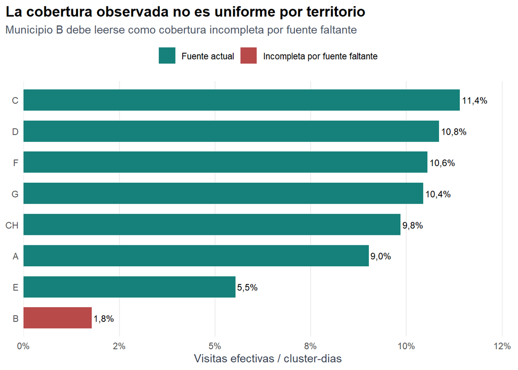

## CCZ Con Mayor Y Menor Cobertura

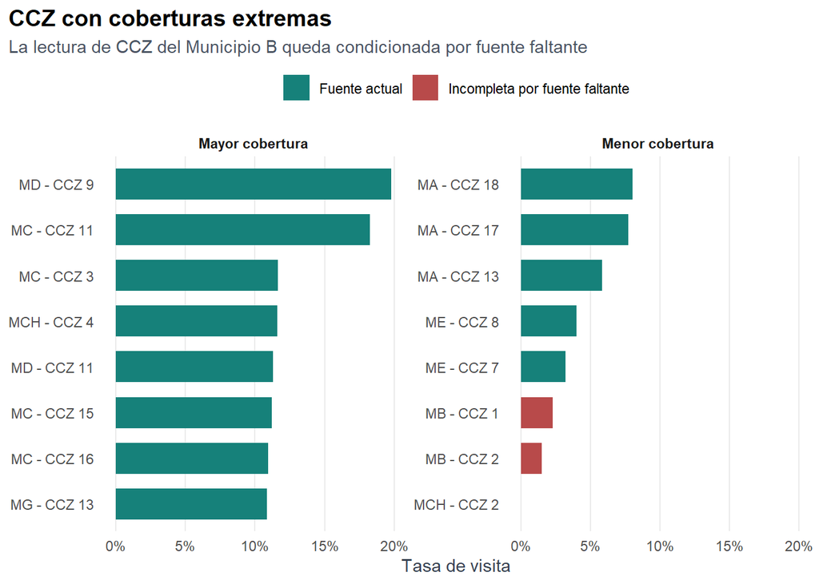

## Correspondencia Entre Problemas ZL Y Reclamos COM

Esta sección mira otra fuente de sesgo: no ya donde observa Zona Limpia, sino en que territorios los problemas observados por Zona Limpia aparecen también como reclamos COM.

La métrica principal es:

```
tasa_com_dado_zl_problema = ambos / problemas observados por Zona Limpia
```

Es decir, de todos los cluster-días donde Zona Limpia registro un problema comparable, que proporcion tuvo además reclamo COM en el mismo cluster-día. Municipio B se excluye de este calculo por la fuente faltante ya documentada.

Correspondencia global entre problemas observados por Zona Limpia y COM, excluyendo Municipio B

| Indicador | Valor |
| --- | --- |
| Cluster-dias observados | 123.731 |
| Problemas ZL comparables | 62.239 |
| Reclamos COM | 11.437 |
| Ambos | 6.700 |
| COM dado problema ZL | 10,8% |
| Problema ZL sin COM | 89,2% |

Correspondencia COM-Zona Limpia por municipio

| Municipio | Problemas ZL | COM | Ambos | COM dado problema ZL | Problema ZL sin COM | Problemas ZL / COM |
| --- | --- | --- | --- | --- | --- | --- |
| F | 11.090 | 1.057 | 718 | 6,5% | 93,5% | 10.49 |
| G | 10.370 | 1.470 | 890 | 8,6% | 91,4% | 7.05 |
| A | 10.633 | 1.430 | 963 | 9,1% | 90,9% | 7.44 |
| D | 11.139 | 1.644 | 1.069 | 9,6% | 90,4% | 6.78 |
| E | 5.661 | 1.402 | 862 | 15,2% | 84,8% | 4.04 |
| C | 8.995 | 2.631 | 1.393 | 15,5% | 84,5% | 3.42 |
| CH | 4.351 | 1.803 | 805 | 18,5% | 81,5% | 2.41 |

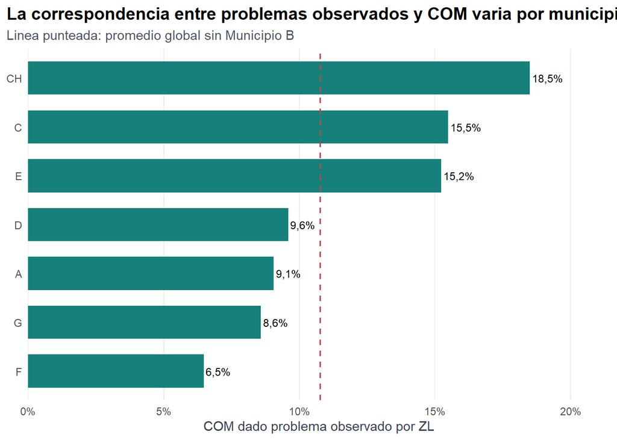

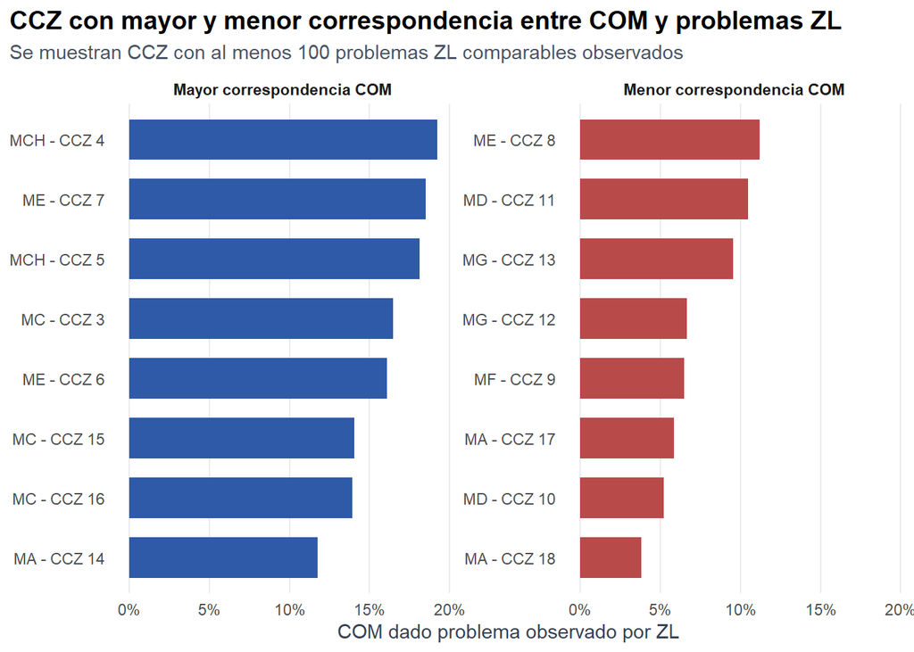

La lectura inicial es que COM captura una fraccion pequena de los problemas que Zona Limpia observa en campo. Además, esa fraccion no es territorialmente uniforme: municipios como F, G, A y D muestran menor correspondencia relativa, mientras CH, C y E muestran mayor correspondencia. Esto sugiere que entrenar o evaluar modelos solo contra COM puede mezclar riesgo real de problema con propensión territorial a reclamar.

### Ajuste Exploratorio Por Propensión De Visita

La lectura anterior está condicionada por la selección de Zona Limpia: los puntos visitados no son una muestra aleatoria. Para explorar cuanto cambia el resultado al corregir por la selección observable, se entrena un modelo liviano de propensión de visita ZL.

Target:

```
P(visita efectiva ZL | features previas de levante, territorio y calendario)
```

El modelo excluye Municipio B, usa todas las visitas ZL y una muestra de no visitados como controles. Las probabilidades se corrigen por la prevalencia real de visita y se usan pesos estabilizados:

```
peso = prevalencia observada de visita / propension estimada de visita
```

Este ajuste no transforma el resultado en una verdad poblacional definitiva, pero permite revisar si el ratio COM-ZL depende fuertemente de la regla de selección observable.

Desempeno del modelo exploratorio de propension de visita

| Escenario | N | Visitas ZL | Prevalencia muestra | Prevalencia real | AUC | Logloss ajustada |
| --- | --- | --- | --- | --- | --- | --- |
| validacion_muestra_control | 101.799 | 25.593 | 25,1% | 9,6% | 0.706 | 0.613 |

Correspondencia global cruda y ajustada por propension de visita

| Metodo | Problemas ZL / COM | Solo ZL problema / COM | COM dado problema ZL | Problema ZL sin COM |
| --- | --- | --- | --- | --- |
| Crudo observado | 5.44 | 4.86 | 10,8% | 89,2% |
| Ajustado por propension | 5.65 | 5.07 | 10,3% | 89,7% |

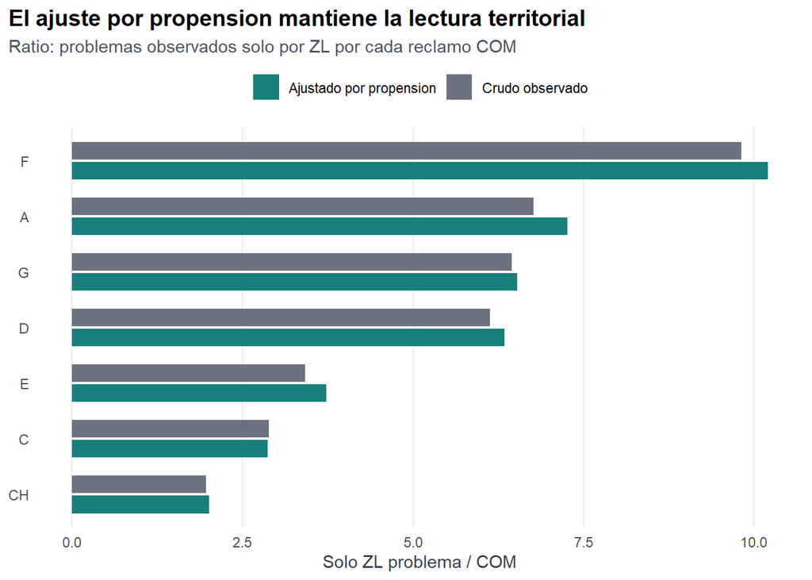

Resultado inicial: el ajuste por propensión no reduce la hipotesis de subreclamo. Globalmente, el ratio `problemas ZL / COM` pasa de `5,44` crudo a `5,65` ajustado; el ratio `solo ZL problema / COM` pasa de `4,86` a `5,07`. Por municipio, F sigue siendo el caso más extremo y queda alrededor de `10,2` problemas observados solo por ZL por cada reclamo COM.

## Criterio Asociado A Levantes

Se explora si la selección de Zona Limpia se asocia con el atraso respecto al período teórico de levante.

Variable principal:

```
exceso_mean_tiempo_periodo_pred_trunc_7 =
  min(max(mean_tiempo_desde_ultimo_levante_pred - mean_levante_periodo, 0), 7)
```

Interpretación:

- `0`: el tiempo desde último levante no supera el período teórico promedio;
- `1`: el cluster está aproximadamente un día por encima del período teórico;
- `7`: el exceso se trunca para no dejar que extremos dominen el análisis.

Visitas y problemas por exceso sobre periodo teorico

| Exceso medio truncado | Cluster-dias | Visitas ZL | Tasa visita | Tasa problema en visitas | Problemas observados COM/ZL | Tasa problema real |
| --- | --- | --- | --- | --- | --- | --- |
| 0 | 928.459 | 66.585 | 7,2% | 44,3% | 125.650 | 13,5% |
| 0-1 | 276.777 | 32.236 | 11,6% | 52,1% | 49.631 | 17,9% |
| 1-2 | 142.750 | 18.762 | 13,1% | 55,0% | 30.111 | 21,1% |
| 2-3 | 59.345 | 8.007 | 13,5% | 59,2% | 13.932 | 23,5% |
| 3-5 | 32.452 | 3.577 | 11,0% | 59,0% | 7.681 | 23,7% |
| 5-7 | 6.292 | 476 | 7,6% | 51,9% | 1.341 | 21,3% |

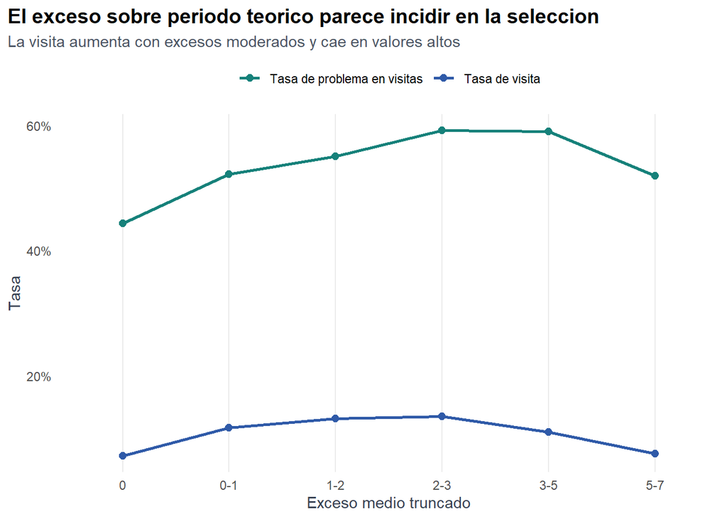

## Comparación Visitados vs No Visitados

Variables de levante en cluster-dias visitados y no visitados

| Variable | Grupo | Media | Mediana | P75 | P90 |
| --- | --- | --- | --- | --- | --- |
| exceso_mean_tiempo_periodo_pred_trunc_7 | Visitado por ZL | 0.59 | 0.00 | 0.93 | 1.93 |
| exceso_mean_tiempo_periodo_pred_trunc_7 | No visitado | 0.43 | 0.00 | 0.49 | 1.51 |
| mean_ratio_tiempo_periodo_pred | Visitado por ZL | 1.06 | 0.97 | 1.45 | 1.90 |
| mean_ratio_tiempo_periodo_pred | No visitado | 0.89 | 0.79 | 1.21 | 1.73 |
| mean_tiempo_desde_ultimo_levante_pred | Visitado por ZL | 2.30 | 2.18 | 3.24 | 4.25 |
| mean_tiempo_desde_ultimo_levante_pred | No visitado | 1.93 | 1.60 | 2.77 | 3.83 |

## Lectura

Los datos sugieren tres sesgos/patrones relevantes:

- **Territorio:** la cobertura observada no es uniforme. Municipio B debe marcarse como cobertura incompleta hasta integrar la fuente adicional.
- **Reclamo COM:** la proporcion de problemas observados por Zona Limpia que también aparece como COM es baja y varia por territorio.
- **Levante:** las visitas de Zona Limpia se concentran más en clusters con exceso positivo moderado respecto al período teórico de levante.

Esto no prueba causalidad ni reconstruye exactamente la regla operativa usada por Zona Limpia, pero sí indica que las visitas efectivas no son una muestra aleatoria de clusters. Por eso los modelos basados en Zona Limpia deben evaluarse teniendo en cuenta cobertura territorial, cambios temporales de criterio y posibles reglas operativas asociadas a levantes.

En paralelo, los modelos o evaluaciones basados solo en COM deben leerse con cuidado porque pueden reflejar diferencias territoriales de propensión a reclamar, no solo diferencias de riesgo real.